# Chapter 11 Tree-Based Methods

# Gradient Boosted Tree

```r
# setup tuning grid
gbmGrid <- expand.grid(interaction.depth = c(1, 5, 9),
                       n.trees = c(6:10)*10,
                       shrinkage = c(.01, .1),
                       n.minobsinnode = 10)

set.seed(100)
gbmTune <- caret::train(x = trainx,
                y = trainy,
                method = "gbm",
                tuneGrid = gbmGrid,
                metric = "accuracy",
                verbose = FALSE,
                trControl = trainControl(method = "cv",
                           classProbs = TRUE,
                           savePredictions = TRUE))
```

```r
gbmTune
```

```
## Stochastic Gradient Boosting
##
## 1000 samples
##   11 predictor
##    2 classes: 'Female', 'Male'
##
## No pre-processing
## Resampling: Cross-Validated (10 fold)
## Summary of sample sizes: 899, 901, 899, 900, 901, 901, ...
## Resampling results across tuning parameters:
##
##   shrinkage  interaction.depth  n.trees  Accuracy   Kappa
##   0.01       1                   60      0.6628235  0.3275609
##   0.01       1                   70      0.6628235  0.3275609
##   0.01       1                   80      0.6688841  0.3418728
##   0.01       1                   90      0.6668639  0.3375871
##   0.01       1                  100      0.6688841  0.3418728
##   0.01       5                   60      0.6418522  0.2682534
##   0.01       5                   70      0.6518728  0.2914822
##   0.01       5                   80      0.6469128  0.2848269
##   0.01       5                   90      0.6449027  0.2827059
##   0.01       5                  100      0.6489229  0.2927973
##   0.01       9                   60      0.6539033  0.2971737
##   0.01       9                   70      0.6488928  0.2887013
##   0.01       9                   80      0.6468825  0.2855221
##   0.01       9                   90      0.6589637  0.3116482
##   0.01       9                  100      0.6649443  0.3259928
##   0.10       1                   60      0.6619037  0.3280496
##   0.10       1                   70      0.6639237  0.3335332
##   0.10       1                   80      0.6689540  0.3429249
##   0.10       1                   90      0.6639338  0.3288857
##   0.10       1                  100      0.6719647  0.3440548
##   0.10       5                   60      0.6689247  0.3377632
##   0.10       5                   70      0.6669546  0.3332671
##   0.10       5                   80      0.6689546  0.3375650
##   0.10       5                   90      0.6719647  0.3433815
##   0.10       5                  100      0.6639544  0.3267292
##   0.10       9                   60      0.6618536  0.3231605
##   0.10       9                   70      0.6618940  0.3233166
##   0.10       9                   80      0.6579134  0.3157208
##   0.10       9                   90      0.6648740  0.3289806
##   0.10       9                  100      0.6628938  0.3250712
##
## Tuning parameter 'n.minobsinnode' was held constant at a value of 10
## Accuracy was used to select the optimal model using the largest value.
## The final values used for the model were n.trees = 90, interaction.depth =
##  5, shrinkage = 0.1 and n.minobsinnode = 10.
```

# Comparing ROC Curves

Now, let us plot ROC curve for different methods in the same graph.

```r
treebagRoc <- pROC::roc(response = bagTune$pred$obs,
                        predictor = bagTune$pred$Female,
                        levels = rev(levels(bagTune$pred$obs)))
treebagRoc
```

```
##
## Call:
## roc.default(response = bagTune$pred$obs, predictor = bagTune$pred$Female,     levels = rev(levels(bagTune$pred$obs)))
##
## Data: bagTune$pred$Female in 446 controls (bagTune$pred$obs Male) < 554 cases (bagTune$pred$obs Female).
## Area under the curve: 0.6933
```

```r
rfRoc <- pROC::roc(response = rfTune$pred$obs,
             predictor = rfTune$pred$Female,
             levels = rev(levels(rfTune$pred$obs)))
rfRoc
```

```
##
## Call:
## roc.default(response = rfTune$pred$obs, predictor = rfTune$pred$Female,     levels = rev(levels(rfTune$pred$obs)))
##
## Data: rfTune$pred$Female in 2230 controls (rfTune$pred$obs Male) < 2770 cases (rfTune$pred$obs Female).
## Area under the curve: 0.7072
```

```r
gbmRoc <- pROC::roc(response = gbmTune$pred$obs,
              predictor = gbmTune$pred$Female,
              levels = rev(levels(gbmTune$pred$obs)))
gbmRoc
```

```
##
## Call:
## roc.default(response = gbmTune$pred$obs, predictor = gbmTune$pred$Female,     levels = rev(levels(gbmTune$pred$obs)))
##
## Data: gbmTune$pred$Female in 13380 controls (gbmTune$pred$obs Male) < 16620 cases (gbmTune$pred$obs Female).
## Area under the curve: 0.6963
```

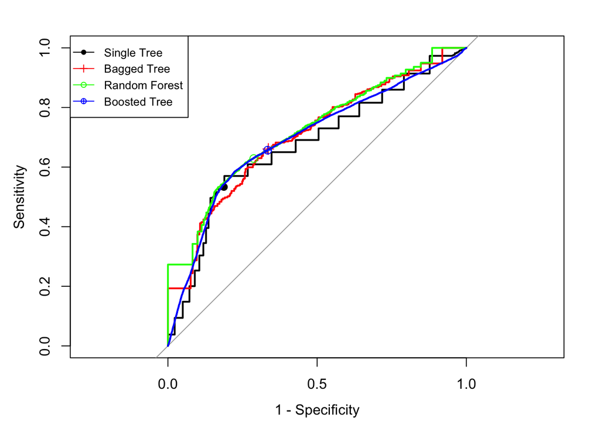

```r
plot.roc(rpartRoc,
     type = "s",
     print.thres = c(.5),
     print.thres.pch = 16,
     print.thres.pattern = "",
     print.thres.cex = 1.2,
     col = "black", legacy.axes = TRUE,
     print.thres.col = "black")

plot.roc(treebagRoc,
     type = "s",
     add = TRUE, print.thres = c(.5),
     print.thres.pch = 3, legacy.axes = TRUE, print.thres.pattern = "",
     print.thres.cex = 1.2,
     col = "red", print.thres.col = "red")

plot.roc(rfRoc,
     type = "s",
     add = TRUE, print.thres = c(.5),
     print.thres.pch = 1, legacy.axes = TRUE, print.thres.pattern = "",
     print.thres.cex = 1.2,
     col = "green", print.thres.col = "green")

plot.roc(gbmRoc,
     type = "s",
     add = TRUE, print.thres = c(.5),
     print.thres.pch = 10, legacy.axes = TRUE, print.thres.pattern = "",
     print.thres.cex = 1.2,
     col = "blue", print.thres.col = "blue")

legend("topleft", cex = 0.8,
       c("Single Tree", "Bagged Tree", "Random Forest", "Boosted Tree"),
       lwd = c(1, 1, 1, 1),
       col = c("black", "red", "green", "blue"),
       pch = c(16, 3, 1, 10))
```

Since the data here doesn’t have many variables, we don’t see a significant difference among the models. But you can still see those ensemble methods are better than a single tree. In most of the real applications, ensemble methods perform much better. Random forest and boosting trees can be a baseline model. Before exploring different models, you can quickly run a random forest to see the performance and then try to improve that performance. If the performance you got from the random forest is not too much better than guessing, you should consider collecting more data or reviewing the problem to frame it a different way instead of trying other models. Because it usually means the current data is not enough to solve the problem.